# Pi Code Demonstration in R

# Introduction

With PI as our “posterchild” code we want to show you how similar the code appears between language. As well as the [sometimes] passive-aggressive differences.

Here we are doing with R.

R technically is not supposed to be a programming language, but rather a statistical software resource. But since so many fields use statistics, R exists on a lot of people’s machines and it’s free, it is often seen as a path of least resistance when it comes to being a coding platform.

Also the R-Studio environment has created a nice environment for programming not only in R but in other languages.

With the PI example we can crunch PI with the core elements of R without having to use any fancy libraries which is so often the case with R.

Let’s first review the pseudocode.

## Math Behind Approximating Pi

Our approximation method here is based on the arctangent function:

$$\pi =\int^{1}_{0} \frac{4}{1+x^2} dx = 4\arctan1.0$$

We wish to approximate this relationship using Reimann sums, shown here:

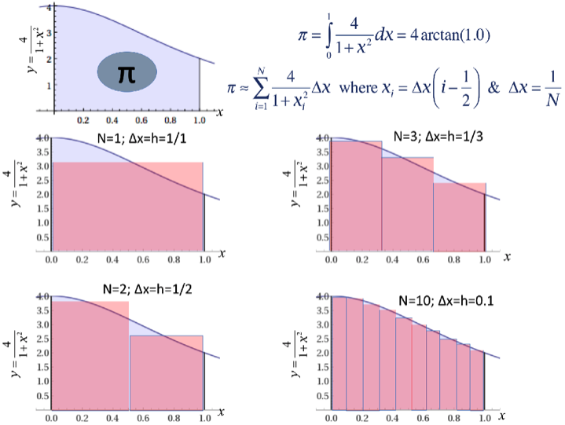

PI Reimann Sum

Doing this we discretize the above integral formula so that for an increment of $\Delta x = 1/N$,

$$\pi =\frac{1}{N}\sum_{i=1}^{N} \frac{4}{1+x^2}$$

## Coding the algorythm in R.

Be aware that when I code in R I am very anal-retentive and use more arguments and elements that many R users have. Functions in R like the [“seq”](https://www.rdocumentation.org/packages/base/versions/3.6.1/topics/seq) function often label the arguments (or variables that are passed into functions). Most users don’t use them if they don’t have to, but I do.

There is also a function we need to make a more detailed “print” statement. That’s the [“paste”](https://www.rdocumentation.org/packages/base/versions/3.6.1/topics/paste) function

```r
N  = 10
pi = 0.0

h  = 1.0 / N

for (n in seq(from = 1,
              to   = N,
              by   = 1) )
  {
      x  = h * (n - 0.5)
      pi = pi + h * (4 / (1 + x^2))

      print(paste("   n = ", n,
                  ";  x = ", x,
                  "; pi = ", pi))

  }
```

```
[1] "   n =  1 ;  x =  0.05 ; pi =  0.399002493765586"
[1] "   n =  2 ;  x =  0.15 ; pi =  0.790200537775366"
[1] "   n =  3 ;  x =  0.25 ; pi =  1.16667112601066"
[1] "   n =  4 ;  x =  0.35 ; pi =  1.52301856476344"
[1] "   n =  5 ;  x =  0.45 ; pi =  1.85565889740378"
[1] "   n =  6 ;  x =  0.55 ; pi =  2.16276062485099"
[1] "   n =  7 ;  x =  0.65 ; pi =  2.44395570393711"
[1] "   n =  8 ;  x =  0.75 ; pi =  2.69995570393711"
[1] "   n =  9 ;  x =  0.85 ; pi =  2.93217631351621"
[1] "   n =  10 ;  x =  0.95 ; pi =  3.1424259850011"
```

## Making arrays to create a plot

Working with R and arrays cen be done serveral ways. Here is one that does what we need with “Maximum Satisfaction with Minimal Effort”

Here we use that sequence function from above and then we “clone” that newly made array by just setting a new array equal to the old one (and in this case, multiupying it by zero).

```r
#####################################################
#
# Creating two arrays for plotting
#

N_array   = seq(from =  1,   # using the sequence functiom to make a
                to   =  N,   # series going from 1 to N
                by   =  1)

pi_array = N_array * 0.0  # playing it lazy!

#
#####################################################
```

And now we wrap this N_array loop around our original psuedocode loop

```r
#####################################################
#
# We first create an outer look with the N_array
#

for (N in N_array)
  {

      h     = 1.0 / N
      pi[N] = 0

      for (n in seq(from = 1,
                    to   = N,
                    by   = 1) )
      {
          x     = h * (n - 0.5)
          pi[N] = pi[N] + h * (4 / (1 + x^2))
      }

      print(paste("  N = ", N, "; pi = ", pi[N]))

  }
```

```
[1] "  N =  1 ; pi =  3.2"
[1] "  N =  2 ; pi =  3.16235294117647"
[1] "  N =  3 ; pi =  3.1508492098656"
[1] "  N =  4 ; pi =  3.14680051839394"
[1] "  N =  5 ; pi =  3.14492586400333"
[1] "  N =  6 ; pi =  3.14390742722244"
[1] "  N =  7 ; pi =  3.14329331752747"
[1] "  N =  8 ; pi =  3.14289472959169"
[1] "  N =  9 ; pi =  3.14262145655761"
[1] "  N =  10 ; pi =  3.1424259850011"
```

```r
#
#####################################################
```

## Ploting our results

There are simple ways to make a plot in R and there are very fancy ways to make professional looking graphics in R.

In this example we’re going to make a very simple one.

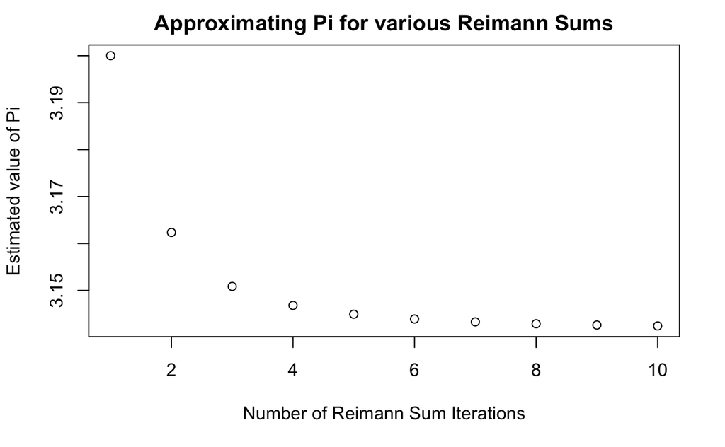

```r
#####################################################
#
# We first create an outer look with the N_array
#

plot(x     = N_array,
     y     = pi,
     main  = "Approximating Pi for various Reimann Sums",
     ylab  = "Estimated value of Pi",
     xlab  = "Number of Reimann Sum Iterations")
```

```r
#
#####################################################
```